# Tipología y ciclo de vida de los datos. Práctica 2

Baltasar Boix / Yago Ezcurra

13/5/2021

Titanic - Machine Learning from Disaster. Kaggle competition.

```r
require(tidyverse)
require(lares)
require(GGally)
require(knitr)
require(kableExtra)
require(gridExtra)
require(DescTools)
```

# 1 Descripción del dataset. ¿Por qué es importante y qué pregunta/problema pretende responder?

## 1.1 Lectura y analisis previo del dataset.

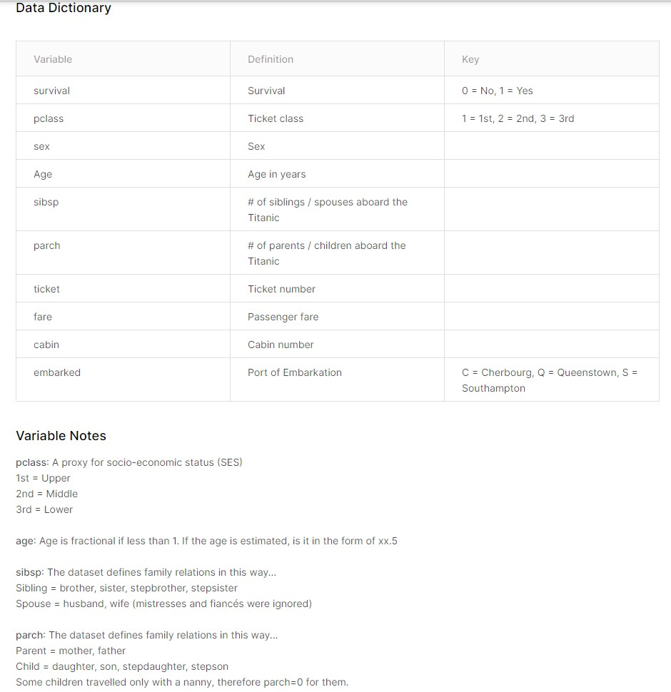

Descripción del dataset obtenido en Kaggle

```r
df <- read_csv('../data/train.csv')

df$Survived <- factor(df$Survived)
df$Pclass <- factor(df$Pclass)
df$Sex <- factor(df$Sex)
df$SibSp <- factor(df$SibSp)
df$Parch <- factor(df$Parch)
df$Embarked <- factor(df$Embarked)

summary(df)
```

```
##   PassengerId    Survived Pclass      Name               Sex
##  Min.   :  1.0   0:549    1:216   Length:891         female:314
##  1st Qu.:223.5   1:342    2:184   Class :character   male  :577
##  Median :446.0            3:491   Mode  :character
##  Mean   :446.0
##  3rd Qu.:668.5
##  Max.   :891.0
##
##       Age        SibSp   Parch      Ticket               Fare
##  Min.   : 0.42   0:608   0:678   Length:891         Min.   :  0.00
##  1st Qu.:20.12   1:209   1:118   Class :character   1st Qu.:  7.91
##  Median :28.00   2: 28   2: 80   Mode  :character   Median : 14.45
##  Mean   :29.70   3: 16   3:  5                      Mean   : 32.20
##  3rd Qu.:38.00   4: 18   4:  4                      3rd Qu.: 31.00
##  Max.   :80.00   5:  5   5:  5                      Max.   :512.33
##  NA's   :177     8:  7   6:  1
##     Cabin           Embarked
##  Length:891         C   :168
##  Class :character   Q   : 77
##  Mode  :character   S   :644
##                     NA's:  2
##
##
##
```

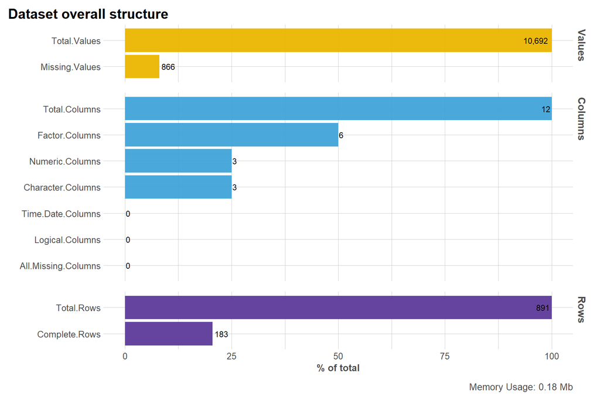

```r
df_str(df)
```

Creamos la variable dicotómica `Child` para diferenciar los niños de los adultos (>12años).

Creamos la variable `n_ticket` con el número de peraonas que viajan con el mismo ticket.

Separamos del `Name` el título (`title_name`) y el primer apellido (`first_name`).

Simplificamos `title_name` en cuatro niveles.

# 2 Integración y selección de los datos de interés a analizar.

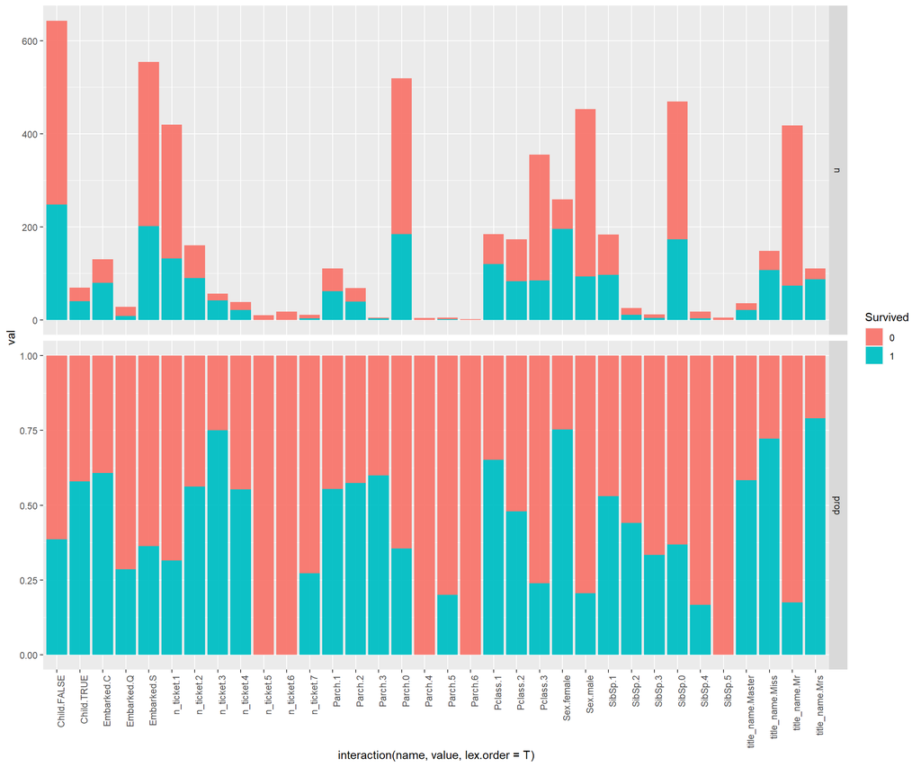

```r
df <- df %>%
  mutate(Child=factor(Age<=12))

df <- left_join(df, df %>%
                  group_by(Ticket) %>%
                  summarize(n_ticket=n())) %>%
  mutate(n_ticket=factor(n_ticket))

df <- df %>%
  separate(Name, c('first_name', 'rest_name'), sep=', ', remove=F) %>%
  separate(rest_name, c('title_name', 'rest_name'), sep='\\.') %>%
  select(-rest_name)

df$title_name[df$title_name %in% c('Capt', 'Col', 'Don', 'Dr', 'Jonkheer', 'Major', 'Rev', 'Sir')] <- 'Mr'
df$title_name[df$title_name %in% c('Lady', 'Mme','the Countess')] <- 'Mrs'
df$title_name[df$title_name %in% c('Mlle', 'Ms')] <- 'Miss'
df$title_name <- factor(df$title_name)

df %>%
  select(where(is.factor)) %>%
  na.omit() %>%
  pivot_longer(-Survived) %>%
  group_by(name, value, Survived) %>%
  summarize(n=n()) %>%
  mutate(prop=prop.table(n)) %>%
  pivot_longer(c(n,prop), names_to='tipo', values_to='val') %>%
  ggplot(aes(x=interaction(name,value, lex.order = T), y=val, fill=Survived)) +
    geom_bar(stat='identity', position='stack') +
    facet_grid(tipo ~ ., scale='free_y') +
    theme(axis.text.x = element_text(angle = 90, vjust = 1, hjust=1))
```

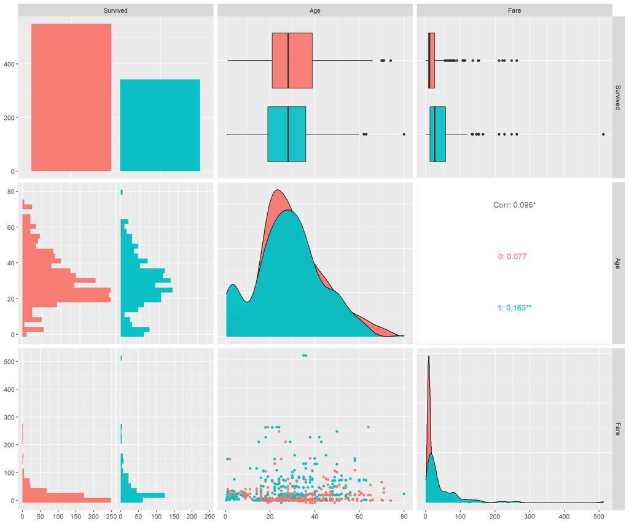

```r
df %>%
  select(Survived, where(is.numeric), -PassengerId) %>%
  ggpairs(aes(color=Survived))
```

# 3 Limpieza de los datos.

## 3.1 ¿Los datos contienen ceros o elementos vacíos? ¿Cómo gestionarías cada uno de estos casos?

Sustituimos los NA’s de la variable Child con los siguientes criterios:

Asumimos que los viajeros con ticket unipersonal con SibSp==0 (sin hermanos o esposa a bordo) y Parch==0 (sin hermanos o padres a bordo) no son niños.

Asumimos que las personas con title_name==‘Mrs’ (mujeres casadas) no son niños.

Asumimos que las personas con title_name==‘Master’ son niños.

Asumimos que las personas con SibSp>0 y Parch>0 son niños.

```r
df <- df %>%
  mutate(Child=if_else(SibSp==0 & Parch==0 & is.na(Child) & n_ticket==1, FALSE, as.logical(Child))) %>%
  mutate(Child=if_else(title_name=='Master' & is.na(Child), TRUE, as.logical(Child))) %>%
  mutate(Child=if_else(title_name=='Mrs' & is.na(Child), FALSE, as.logical(Child))) %>%
  mutate(Child=if_else(SibSp > '0' & Parch > '0' & is.na(Child), TRUE, as.logical(Child))) %>%
  mutate(Child=if_else(is.na(Child), FALSE, as.logical(Child)))


prop.table(table(df$Survived, df$Child, dnn=c('Survived', 'Child')), margin=2)
```

```
##         Child
## Survived     FALSE      TRUE
##        0 0.6332518 0.4246575
##        1 0.3667482 0.5753425
```

## 3.2 Identificación y tratamiento de valores extremos.

# 4 Análisis de los datos.

## 4.1 Selección de los grupos de datos que se quieren analizar/comparar (planificación de los análisis a aplicar).

## 4.2 Comprobación de la normalidad y homogeneidad de la varianza.

## 4.3 Aplicación de pruebas estadísticas para comparar los grupos de datos. En función de los datos y el objetivo del estudio, aplicar pruebas de contraste de hipótesis, correlaciones, regresiones, etc. Aplicar al menos tres métodos de análisis diferentes.

```r
df %>%
  select(Survived, where(is.factor)) %>%
  pivot_longer(-Survived) %>%
  group_by(name) %>%
  summarize(phi=Phi(x=Survived, y=factor(value)),
            chisq.pvalue=chisq.test(Survived, factor(value))$p.value) %>%
  mutate(`signif 95%`=chisq.pvalue < 0.05) %>%
  arrange(chisq.pvalue) %>%
  kable(format='html', digits=4, caption='<b>Phi y chisq.test</b>') %>%
  kable_styling(full_width = F)
```

**Phi y chisq.test**

| name | phi | chisq.pvalue | signif 95% |
| --- | --- | --- | --- |
| title_name | 0.5708 | 0e+00 | TRUE |
| Sex | 0.5434 | 0e+00 | TRUE |
| Pclass | 0.3398 | 0e+00 | TRUE |
| n_ticket | 0.3250 | 0e+00 | TRUE |
| SibSp | 0.2045 | 0e+00 | TRUE |
| Embarked | 0.1726 | 0e+00 | TRUE |
| Parch | 0.1770 | 1e-04 | TRUE |

```r
df %>%
  select(Survived, where(is.numeric), -PassengerId) %>%
  pivot_longer(-Survived) %>%
  group_by(name, Survived) %>%
  summarize(value_list = list(value)) %>%
  pivot_wider(names_from=Survived, values_from=value_list) %>%
  mutate(vartest.pval=var.test(unlist(`0`), unlist(`1`))$p.val) %>%
  mutate(ttest.pval=t.test(unlist(`0`), unlist(`1`), var.equal=vartest.pval>0.05)$p.val) %>%
  mutate(`signif 95%`=ttest.pval < 0.05) %>%
  select(-`0`, -`1`)  %>%
  kable(format='html', digits=4, caption='<b>t.test</b>') %>%
  kable_styling(full_width = F)
```

**t.test**

| name | vartest.pval | ttest.pval | signif 95% |
| --- | --- | --- | --- |
| Age | 0.317 | 0.0391 | TRUE |
| Fare | 0.000 | 0.0000 | TRUE |

# 5 Representación de los resultados a partir de tablas y gráficas.

# 6 Resolución del problema. A partir de los resultados obtenidos, ¿cuáles son las conclusiones? ¿Los resultados permiten responder al problema?